# RNA-seq - EMT-Iron

Nicolas Servant

01th Novembre 2018

```r
rm(list=ls())
require(GenomicRanges)
require(rtracklayer)
require(ggplot2)
require(reshape2)
require(DESeq2)
require(gridExtra)
require(pheatmap)
require(RColorBrewer)
require(genefilter)
require(ggrepel)
require(limma)
require(edgeR)
require(DT)

## PATH and SETTINGS
inPath <- "./"
outPath <- "./"
splan <- read.csv(file.path(inPath, "data/SAMPLE_PLAN"))

## FUNCTIONS
gexprs <- function(x, group, yl="Expression", main=""){
  d <- melt(x)
  d$group <- group
  ggplot(d, aes(x=variable, y=value, fill=group)) + geom_bar(stat = 'identity') + theme_classic() + ggtitle(main) +
    theme(axis.text.x = element_text(angle = 90, hjust = 1)) + ylab(yl) +
    xlab("")
}


LimmaVolcano <- function(res, main="", fct=1.5, pt=0.05){
  res$sign <- 0
  res$sign[which(res$adj.P.Val < pt & abs(res$logFC) > fct)] <- 1

  p <- ggplot(data=res, aes(x=logFC, y=-log10(adj.P.Val), colour=as.factor(sign))) +  geom_point(alpha=0.4, size=2) + scale_color_manual(name="", values=c("1"="red", "0"="black")) + ggtitle(paste0("Volcano Plot - Limma ", main)) + theme(legend.position = "none") +
xlab("log2 fold change") + ylab("-log10 adj pvalue") + geom_vline(xintercept=c(-fct, fct), linetype=2) + geom_hline(yintercept=-log10(pt), linetype=2)
  p
}
```

### Project and Design

Sequencing has been performed using Illumina paired-end 100nt approach. The goal of the project is to compare ‘untreated’ and ‘EGF’ samples.

```r
datatable(splan, colnames=c('IDs','Type', 'Replicate'), rownames = FALSE, escape = FALSE, filter = 'top', caption = 'Experimental design')
```

|  | IDs | Type | Replicate |
| --- | --- | --- | --- |
| D038.D029T01 | T01_UN_1 | untreated | rep1 |
| D038.D029T04 | T04_UN_2 | untreated | rep2 |
| D038.D029T02 | T02_EGF_1 | EGF | rep1 |
| D038.D029T05 | T05_EGF_2 | EGF | rep2 |

### Quality Control and Data processing

Sequencing reads were aligned on the Human reference genome (hg38) using the STAR mapper. Protein-coding genes from the Gencode annotation have been used to generate the raw count table.

The raw counts table can be downloaded from GEO (GSE121663).

Additional quality controls report a very high sequencing quality, a high fraction of mapped reads (>95% of uniquely mapped reads), and a high enrichment in exonic reads (>98%).

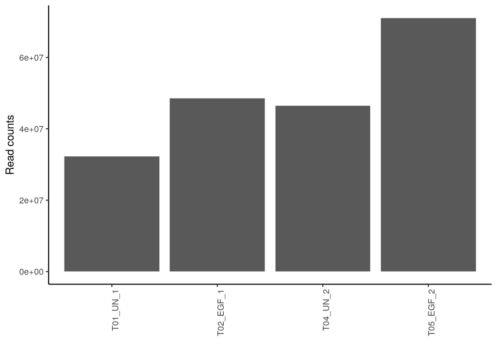

```r
## How many counts per samples
d.counts <- read.csv(file.path(inPath, "data/tablecounts_raw.csv.gz"), header=TRUE, row.names=1)
d.counts <- d.counts[,splan$id]
colnames(d.counts) <- splan[match(splan$id, colnames(d.counts)), "sname"]
rownames(splan) <- splan$sname

ggplot(data.frame(x=colnames(d.counts), cs=colSums(d.counts)), aes(x=x, y=as.numeric(cs))) + geom_bar(stat="identity") + xlab("") + theme_classic() + ylab("Read counts") + theme(axis.text.x = element_text(angle = 90, hjust = 1))
```

```r
## remove all zeros
d.counts <- d.counts[which(rowSums(d.counts)>0),]
```

## Exploratory analysis

Raw counts have been normalized using the *rlog* method in order to stabilize the variance and apply dimension reduction methods.

```r
dds <- DESeqDataSetFromMatrix(countData=d.counts,
                              DataFrame(type=splan$type,
                                        replicate=splan$replicate),
                              design=~ type)
dds <- estimateSizeFactors(dds)
rld <- rlog(dds, blind=TRUE)
```

#### **Principal Component Analysis**

We first run a Principal Component Analysis (PCA) on the most 1000 variable genes.  
Briefly, the goal of such technic is to reduce the data dimension, from *n* gene dimensions to a few ‘principal component’ (PC) that maximize the variability in the data set without any a-priori knowledge. PCs are ordered according to the proportion of variance they explain.

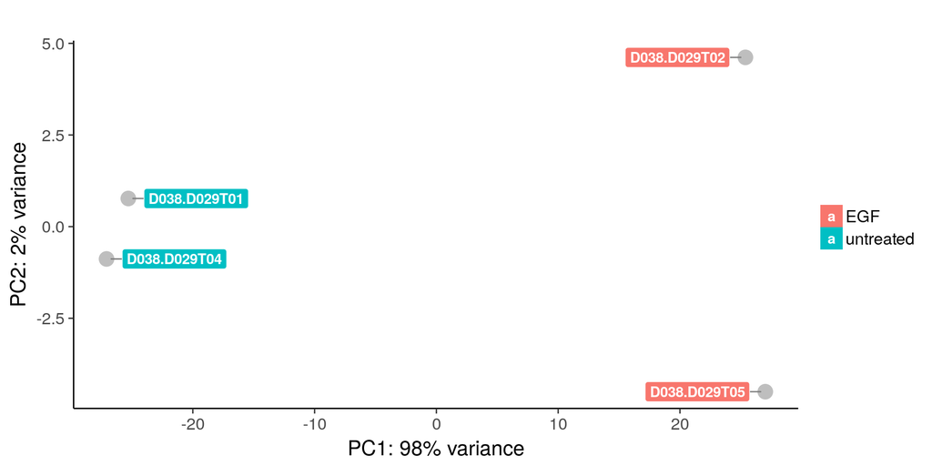

```r
d.rld <- assay(rld)
var_genes <- rowVars(d.rld)
select_var <- order(var_genes, decreasing=TRUE)[1:1000]

pca <- prcomp(t(d.rld[select_var,]))
df <- as.data.frame(pca$x)
df$type <- as.factor(splan[rownames(df),"type"])
df$replicate <- as.factor(splan[rownames(df),"replicate"])
df$name <- splan[rownames(df),"id"]
percentVar <- round(pca$sdev^2/sum(pca$sdev^2)*100)

ggplot(df) + geom_point(aes(PC1, PC2), size=5, color="grey") +
  geom_label_repel(aes(PC1, PC2, fill=type, label=name), fontface='bold', color='white',
      segment.color='grey50', box.padding = unit(0.35, "lines"), point.padding = unit(0.5, "lines")) +
          labs(title="", x=paste0("PC1: ",percentVar[1],"% variance"),
                y=paste0("PC2: ",percentVar[2],"% variance")) +
              theme_classic(base_size = 16) + theme(legend.title=element_blank())
```

As expected, the first component (PC1) is driven by the *EGF* effect (PC1 - 98% of variance).

#### **Hierarchical CLustering of samples**

Another way to look at samples similarity without any a priori knowledge is to perform a hierarchical clustering. Note that here, compared to the PCA, we used all genes in the distance calculation (Euclidean distance, Ward linkage).

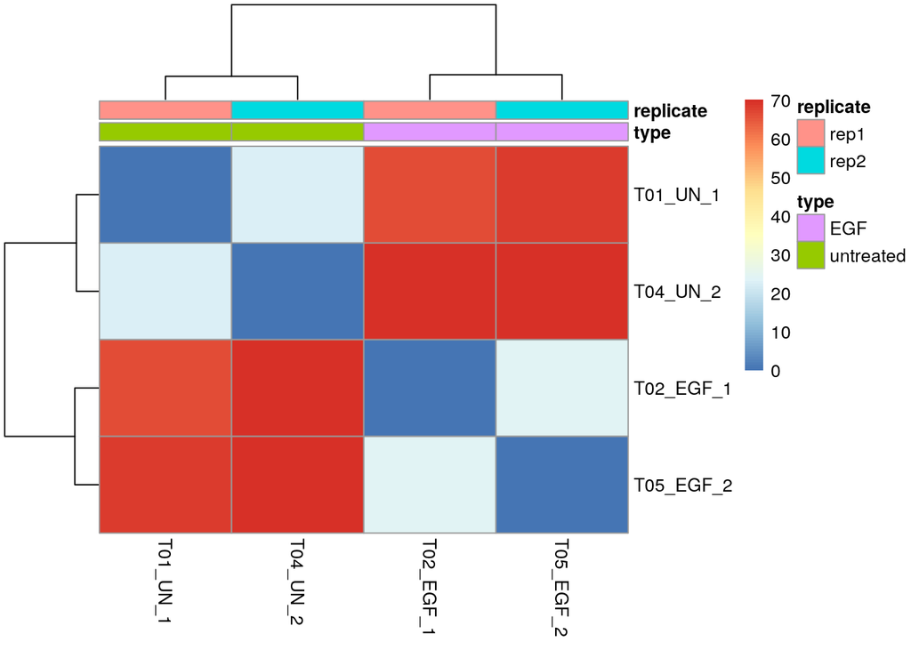

```r
sampleDists <- dist(t(assay(rld)))
cl <- hclust(sampleDists, "ward.D2")
sampleDistMatrix <- as.matrix(sampleDists)
rownames(sampleDistMatrix) <- colnames(rld)
colnames(sampleDistMatrix) <- colnames(rld)
annot <- splan[,c("type", "replicate")]

pheatmap(sampleDistMatrix,
         clustering_distance_rows=sampleDists,
         clustering_distance_cols=sampleDists,
         clustering_method="ward.D2",
         annotation_col=annot)
```

## Differential Analysis

#### **Genes filtering**

Note that in the context of differential analysis, we usually restrict the analysis to ‘expressed’ genes. The expressed genes are those with a TPM (transcripts per million) normalized counts >= 1 in at least one sample.

```r
N <- nrow(d.counts)
## Expressed genes
d.tpm <- read.csv(file.path(inPath, "data/tablecounts_tpm.csv.gz"), header=TRUE, row.names=1)
d.tpm <- d.tpm[,as.vector(splan$id)]
colnames(d.tpm) <- as.vector(splan$sname)
isexpr <- names(which(apply(d.tpm[,colnames(d.counts)], 1, function(x){length(which(x>=1))})>=1))
d.counts.f <- d.counts[isexpr,]
d.tpm.f <- d.tpm[isexpr,]
Nf <- nrow(d.counts.f)
```

In summary, starting from 36688 genes, we are now working with 18499 expressed genes.

#### **Untreated vs EGF comparison**

In order to perform the differential analysis, we design a linear model as follow:

Y <sub>it</sub> = mu <sub>i</sub> + T <sub>t</sub> + E <sub>it</sub>

where T is the *type* effect (T={untreated, EGF}). Expressed raw count have been normalized using the TMM method from the edgeR package. Differential analysis has been performed with the limma/voom R package. All raw p-values were corrected for multiple testing using the Benjamini-Hochberg (BH) method.

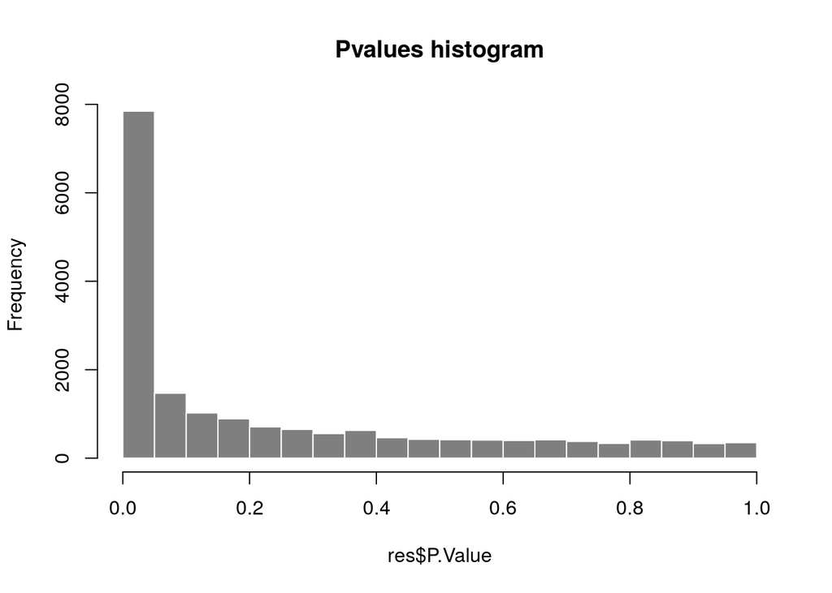

```r
y <- DGEList(counts=d.counts.f, genes=rownames(d.counts.f))
y <- calcNormFactors(y, method="TMM")
design <- model.matrix(~ 0 + type, data=splan)
v <- voom(y, design, plot=FALSE)
fit <- lmFit(v, design)

contrast <-makeContrasts(typeEGF-typeuntreated, levels=design)
fit2 <- contrasts.fit(fit, contrast)
fit2 <- eBayes(fit2)
res <- topTable(fit2, number=nrow(d.counts.f), adjust.method="BH")
res <- res[order(res$adj.P.Val),]

hist(res$P.Value, col="gray50", border="white", main="Pvalues histogram")
```

```r
nsign <- length(which(res$adj.P.Val < 0.05))
nsignfc <- length(which(res$adj.P.Val < 0.05 & abs(res$logFC) > 1))

## save DEG
write.csv(res, file.path(outPath, "DEG_untreated_vs_EGF_wo-release.csv"),
          row.names = FALSE, quote = FALSE)
```

6227 DEG were found significant between untreated and EGF (FDR<5%). Among them 2552 are significant with a log(FC) > 1.

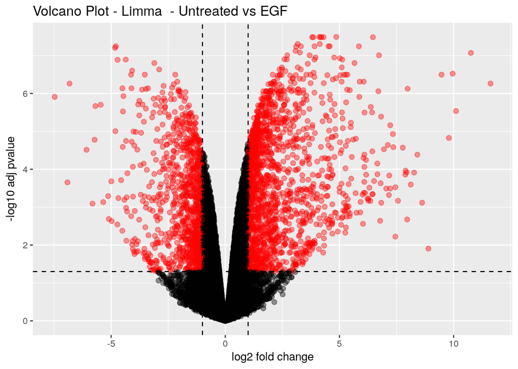

```r
## VolcanoPlot
LimmaVolcano(res, fct=1, pt=0.05, main=" - Untreated vs EGF")
```

#### **Zooming on a few genes of interest**

As a control, let’s focus on a few driver genes …

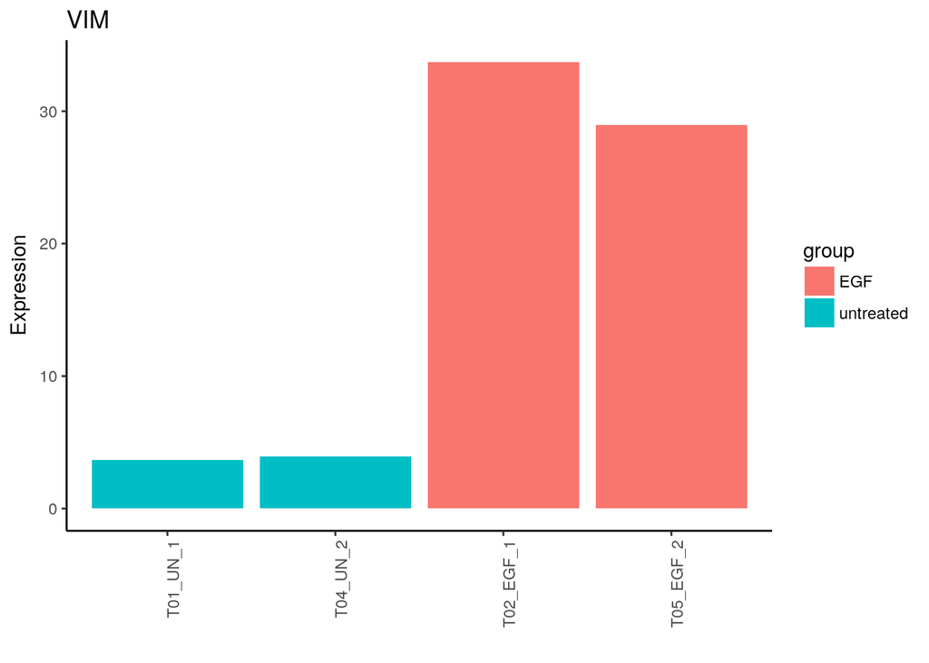

```r
res.fc <- res[order(res$logFC, decreasing = TRUE),]
gexprs(d.tpm[grep("VIM$",rownames(d.tpm)),], group=splan[colnames(d.tpm),"type"], main="VIM")
```

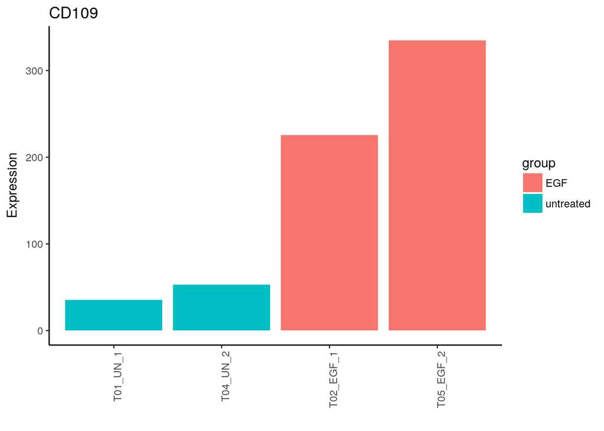

```r
gexprs(d.tpm[grep("CD109",rownames(d.tpm)),], group=splan[colnames(d.tpm),"type"], main="CD109")
```

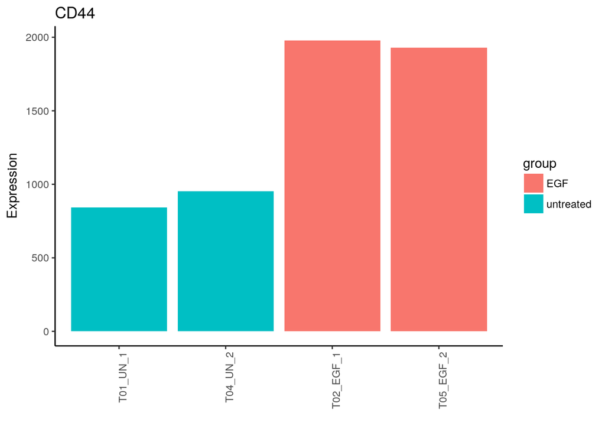

```r
gexprs(d.tpm[grep("CD44",rownames(d.tpm)),], group=splan[colnames(d.tpm),"type"], main="CD44")
```